# lab07

## Lab 7: Working with Dates and Times

**Due Date: Friday March 27, 2020 at 11:59 AM.**

`pandas` supports many methods for manipulating dates and times. For Project 1, we will need to understand timestamps of data scraped from the internet. While we could work with dates and times as strings, it will be helpful for us to understand

- Objects for storing dates / times
- Methods for accessing and modifying dates / times
- Switching between timezones

We will use a financial dataset consisting of information about stock movements.

```python
import datetime
from datetime import datetime
from datetime import timedelta
import pytz

import numpy as np
import pandas as pd

import sys
from IPython.display import Image
```

```python
# TEST

assert 'pandas' in sys.modules and "pd" in locals()
assert 'numpy' in sys.modules and "np" in locals()
assert 'pytz' in sys.modules
assert 'datetime' in sys.modules
```

### 1. Date and Time Data Types

Before studying dates and times in the `pandas` package, we will try to understand objects for storing dates and times. We will use the `datetime` package.

Each `datetime` object consists of year, month and day in the [Gregorian calendar](https://en.wikipedia.org/wiki/Gregorian_calendar).

```python
now = datetime.now()
print(now.year, now.month, now.day)
```

```
2020 3 27
```

Moreover `datetime` objects can store time of day as hours, minutes, seconds, and microseconds

```python
print(now.hour, now.minute, now.second, now.microsecond)
```

```
2 5 6 980530
```

The package allows us to [overload](https://en.wikipedia.org/wiki/Function_overloading) arithmetic operations.

For example, we can determine the elapsed time between two dates by applying subtraction.

```python
delta = datetime(2011, 1, 7) - datetime(2008, 6, 24, 8, 15)
print("Days ", delta.days)
print("Seconds ", delta.seconds)
```

```
Days  926
Seconds  56700
```

Note that the difference between two dates is a `timedelta` object.

```python
type(delta)
```

```
datetime.timedelta
```

We can incorporate `timedelta` objects into arithmetic operations

```python
start = datetime(2011, 1, 7)
finish = start + 2 * timedelta(days = 4)
print(finish.year, finish.month, finish.day)
```

```
2011 1 15
```

### 1.1 Coverting between string and datetime

We can cast a string to a `datetime` object or cast a `datetime` object to a string. For example, if we print a `datetime` object then we get a representation as a string.

```python
stamp = datetime(2011, 1, 3)
str(stamp)
```

```
'2011-01-03 00:00:00'
```

We can adjust the formatting with the following

%Y 4-digit year  
%y 2-digit year  
%m 2-digit month [01, 12]  
%d 2-digit day [01, 31]  
%H Hour (24-hour clock) [00, 23]  
%I Hour (12-hour clock) [01, 12]  
%M 2-digit minute [00, 59]  
%S Second [00, 61] (seconds 60, 61 account for leap seconds)  
%w Weekday as integer [0 (Sunday), 6]  
%z UTC time zone offset as +HHMM or -HHMM, empty if time zone naive

```python
print("Format: (4 digit year) - (2 digit month) - (2 digit day)\n",stamp.strftime('%Y-%m-%d'))
```

```
Format: (4 digit year) - (2 digit month) - (2 digit day)
 2011-01-03
```

If we know the format of a string, then we can convert it to a `datetime` object.

```python
str_date = '201101/03'
datetime.strptime(str_date, '%Y%m/%d')
```

```
datetime.datetime(2011, 1, 3, 0, 0)
```

### 1.2 Using datetime with pandas

Often we want to use `datetime` objects in the index of a `pandas` series or dataframe.

```python
dates = [datetime(2011, 1, 2), datetime(2011, 1, 5), datetime(2011, 1, 7),
         datetime(2011, 1, 8), datetime(2011, 1, 10), datetime(2011, 1, 12)]

ts = pd.Series(np.random.randn(6), index=dates)
ts
```

```
2011-01-02    0.365480
2011-01-05   -1.566869
2011-01-07   -0.393923
2011-01-08    0.569203
2011-01-10   -1.358075
2011-01-12    1.743518
dtype: float64
```

Note that the index is a `DatetimeIndex` meaning a `pandas` data structure that support operations like substraction.

```python
print("Index type", type(ts.index))
```

```
Index type <class 'pandas.core.indexes.datetimes.DatetimeIndex'>
```

Alternatively, we can skip the `datetime` package to convert from a string using `to_datetime` method.

```python
datestrs = ['7/6/2011', '8/6/2011']
pd.to_datetime(datestrs)
```

```
DatetimeIndex(['2011-07-06', '2011-08-06'], dtype='datetime64[ns]', freq=None)
```

Note that we can handle missing dates like missing numbers. Instead of `NaN` we have `NaT`.

```python
date_index = pd.to_datetime(datestrs + [None])
date_index
```

```
DatetimeIndex(['2011-07-06', '2011-08-06', 'NaT'], dtype='datetime64[ns]', freq=None)
```

We can check for missing values with `isna`

```python
pd.isna(date_index)
```

```
array([False, False,  True])
```

### 2. Date Ranges

Often we want to generate many dates according to a pattern.

#### 2.1 Ranges

If we have a starting date and ending date, then we can fill in intermediate dates according to a frequency.

```python
date_index = pd.date_range('4/1/2012', '6/1/2012', freq="D")
date_index[:3]
```

```
DatetimeIndex(['2012-04-01', '2012-04-02', '2012-04-03'], dtype='datetime64[ns]', freq='D')
```

If we have a starting date, then we can add a certain number of periods according to a frequency.

```python
pd.date_range(start='4/1/2012', periods=20, freq="M")[:3]
```

```
DatetimeIndex(['2012-04-30', '2012-05-31', '2012-06-30'], dtype='datetime64[ns]', freq='M')
```

#### 2.2 Access

We have different ways to access the dates. For example, we could specify either a string or a `datetime` object corresponding to a particular entry

```python
ts = pd.Series(np.random.randn(1000),
                   index=pd.date_range('1/1/2000', periods=1000))
ts.head()
```

```
2000-01-01    1.893933
2000-01-02    1.055644
2000-01-03   -0.200939
2000-01-04    0.055476
2000-01-05    0.029750
Freq: D, dtype: float64
```

```python
ts['2000-01-10']
```

```
0.58949991519795
```

```python
ts[datetime(2000, 1, 7)]
```

```
0.13869718691869407
```

If we want a collection of dates, then we could specify less information.

```python
ts['2001'].head()
```

```
2001-01-01   -0.663081
2001-01-02    0.965041
2001-01-03    1.211227
2001-01-04   -0.645281
2001-01-05   -1.671691
Freq: D, dtype: float64
```

```python
ts['2001-05'].head()
```

```
2001-05-01   -0.526701
2001-05-02   -0.897810
2001-05-03   -1.068722
2001-05-04   -0.687479
2001-05-05    0.465338
Freq: D, dtype: float64
```

Or we could specify a slice of dates like a slice of numbers.

```python
ts[datetime(2001, 1, 7):].head()
```

```
2001-01-07    1.468223
2001-01-08    0.835148
2001-01-09    0.675756
2001-01-10   -0.105051
2001-01-11   -0.487295
Freq: D, dtype: float64
```

```python
ts['1/6/2001':'2/10/2001'].head()
```

```
2001-01-06    0.859308
2001-01-07    1.468223
2001-01-08    0.835148
2001-01-09    0.675756
2001-01-10   -0.105051
Freq: D, dtype: float64
```

### 3. Time Zones

We will use the `pytz` package to deal with timezones. The package recognizes timezones according to strings.

```python
pytz.common_timezones[-5:]
```

```
['US/Eastern', 'US/Hawaii', 'US/Mountain', 'US/Pacific', 'UTC']
```

```python
est_tz = pytz.timezone('US/Eastern')
est_tz
```

```
<DstTzInfo 'US/Eastern' LMT-1 day, 19:04:00 STD>
```

By default a `DatetimeIndex` does not have an associated timezone. We can check by accessing the `tz` attribute of the index.

```python
rng = pd.date_range('3/9/2012 9:30', periods=6, freq='D')
print(rng.tz)
```

```
None
```

```python
rng = pd.date_range('3/9/2012 9:30', periods=10, freq='D', tz='UTC')
print(rng.tz)
```

```
UTC
```

We can add timezones to an existing `DatetimeIndex` using the `tz_localize` method.

```python
rng = pd.date_range('3/9/2012 9:30', periods=6, freq='D')
rng_utc = rng.tz_localize('UTC')
rng_utc[:3]
```

```
DatetimeIndex(['2012-03-09 09:30:00+00:00', '2012-03-10 09:30:00+00:00',
               '2012-03-11 09:30:00+00:00'],
              dtype='datetime64[ns, UTC]', freq='D')
```

If we have included the timezone, then we can convert using the `tz_convert` method.

```python
rng_utc.tz_convert('US/Eastern')[:3]
```

```
DatetimeIndex(['2012-03-09 04:30:00-05:00', '2012-03-10 04:30:00-05:00',
               '2012-03-11 05:30:00-04:00'],
              dtype='datetime64[ns, US/Eastern]', freq='D')
```

## Questions

We have stock market data in `raw_data.csv`

```python
df_raw = pd.read_csv("raw_data.csv")

df_raw.head(3)
```

|  | Volume | Price | times_of_trade |
| --- | --- | --- | --- |
| 0 | 29184000 | 222.149994 | 16-10-2018 13:00:00 |
| 1 | 40925500 | 215.089996 | 24-10-2018 22:00:00 |
| 2 | 53124400 | 214.449997 | 11-10-2018 16:00:00 |

Note that the entries of the column `times_of_trade` are strings representing dates and times in the form `dd-mm-yyyy hh:mm:ss`. While each time refers to `PST` timezone, the format is `GMT` timezone.

Generate another `pd.DataFrame` called `df` from `df_raw` through the following operations:

- Replace `times_of_trade` with `Time`
- Use `pd.to_datetime` to convert each string in `Time`. Remember that the format is `dd-mm-yyyy hh:mm:ss`
- Add the timezone `UTC'. Set the timezone to 'US/Pacific'.
- Apply `sort_values` to sort by the entries in `Time`
- Invoke `set_index` to set the index to be `Time`

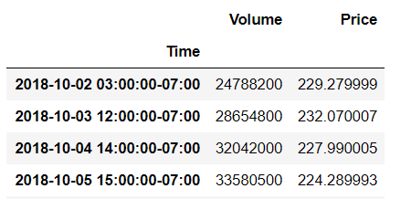

```python
Image("table.PNG")
```

```python
df = df_raw.rename(columns={'times_of_trade':'Time'})
df['Time']=pd.to_datetime(df['Time'], format='%d-%m-%Y %H:%M:%S' )
df['Time']=df['Time'].dt.tz_localize('UTC')
df['Time']=df['Time'].dt.tz_convert('US/pacific')
df=df.sort_values(by='Time')
df=df.set_index('Time')
df
```

| Time | Volume | Price |
| --- | --- | --- |
| 2018-10-02 03:00:00-07:00 | 24788200 | 229.279999 |
| 2018-10-03 12:00:00-07:00 | 28654800 | 232.070007 |
| 2018-10-04 14:00:00-07:00 | 32042000 | 227.990005 |
| 2018-10-05 15:00:00-07:00 | 33580500 | 224.289993 |
| 2018-10-08 08:00:00-07:00 | 29663900 | 223.770004 |
| 2018-10-09 13:00:00-07:00 | 26891000 | 226.869995 |
| 2018-10-10 16:00:00-07:00 | 41990600 | 216.360001 |
| 2018-10-11 09:00:00-07:00 | 53124400 | 214.449997 |
| 2018-10-12 06:00:00-07:00 | 40337900 | 222.110001 |
| 2018-10-15 07:00:00-07:00 | 30791000 | 217.360001 |
| 2018-10-16 06:00:00-07:00 | 29184000 | 222.149994 |
| 2018-10-17 10:00:00-07:00 | 22885400 | 221.190002 |
| 2018-10-18 07:00:00-07:00 | 32581300 | 216.020004 |
| 2018-10-19 08:00:00-07:00 | 33078700 | 219.309998 |
| 2018-10-22 04:00:00-07:00 | 28792100 | 220.649994 |
| 2018-10-23 12:00:00-07:00 | 38767800 | 222.729996 |
| 2018-10-24 15:00:00-07:00 | 40925500 | 215.089996 |
| 2018-10-25 05:00:00-07:00 | 29855800 | 219.800003 |
| 2018-10-26 06:00:00-07:00 | 47258400 | 216.300003 |
| 2018-10-29 15:00:00-07:00 | 45935500 | 212.240005 |
| 2018-10-30 15:00:00-07:00 | 36660000 | 213.300003 |
| 2018-10-31 03:00:00-07:00 | 38358900 | 218.860001 |
| 2018-11-01 10:00:00-07:00 | 56810000 | 222.220001 |

```python
# TEST

assert set(df.columns) == {'Volume', "Price"}
```

```python
# TEST

assert df.index[0] < df.index[1]
```

```python
# TEST

assert type(df.index) == pd.core.indexes.datetimes.DatetimeIndex
```